# Final project - HIV prevalence in Lesotho

Giulia Rathmes

2023-01-31

# HIV prevalence by region in Lesotho 2014

Across the 3,321 surveyed women (ages 15 to 49), 934 women (28.1%) had HIV.

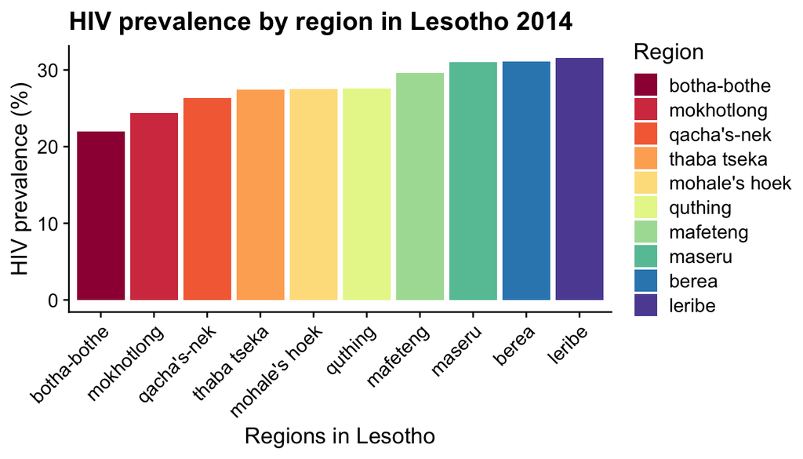

HIV prevalence by region in Lesotho 2014

Figure 1 shows the HIV prevalence by region. Leribe is the region with the highest prevalence of HIV (32%), whereas Botha-Bothe had the lowest prevalence (22%) of HIV in 2014.

# Demographics in Leribe and Botha-Bothe

### a. Age distrubtion of women in Leribe vs. Botha-Bothe

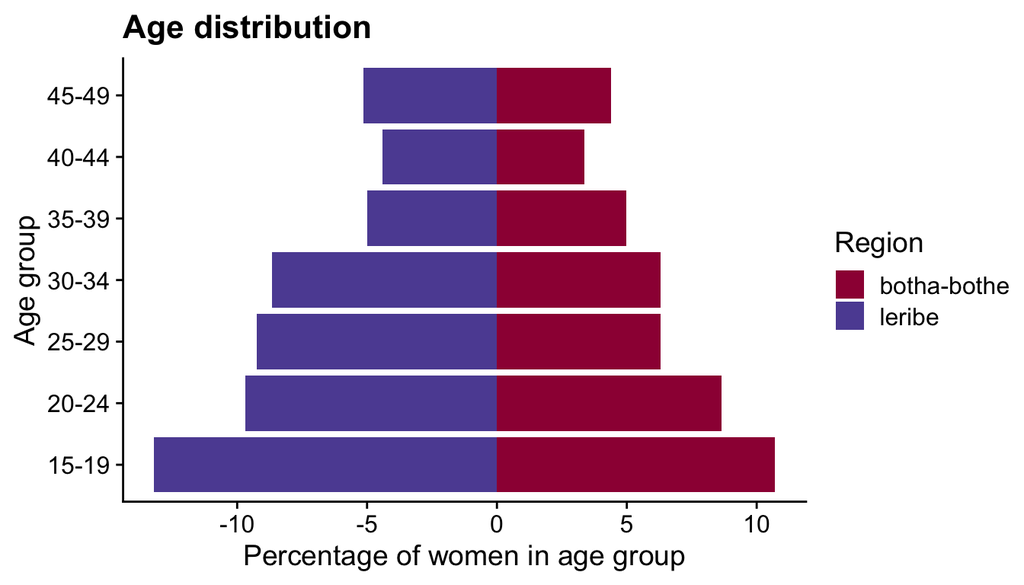

Age distribution in Leribe vs. Botha-Bothe

Figure 2 illustrates the age distribution in Leribe, the region with the highest HIV prevalence, versus Botha-Bothe, the region with the lowest HIV prevalence. The distribution of age was similar in Leribe to Botha-Bothe.

### b. Educational status of women in Leribe vs. Botha-Bothe

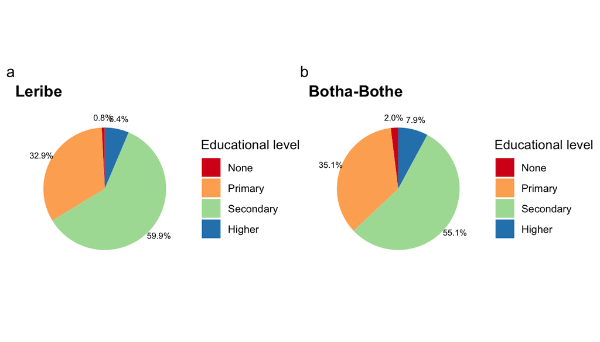

Level of education in Leribe vs. Botha-Bothe

Figure 3 illustrates the level of education in women aged 15-49 in Leribe vs. Botha-Bothe. The educational background was similar in Leribe to Botha-Bothe. In Leribe 66.3% and in Botha-Bothe 63% had achieved secondary education or higher.

### c. Number of sexual partners in Leribe vs. Botha-Bothe

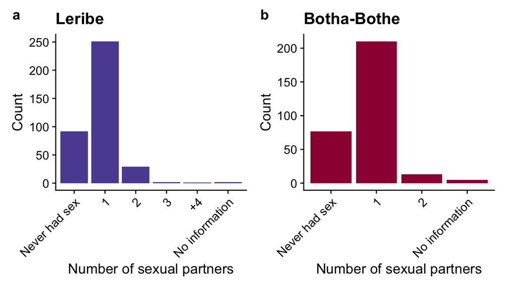

Number of sexual partners in Leribe vs. Botha-Bothe

Figure 4 shows the number of sexual partners in Leribe, the region with the highest HIV prevalence, and in Botha-Bothe, the region with the lowest HIV prevalence. In Leribe, 8% of women aged 15-49 had sex with two or more sexual partners, whereas 24% never had sex. In Botha-Bothe, 4% had sex with two or more sexual partners, whereas 25% never had sex.

# Analysis of demographic variables and HIV prevalence

### a. HIV Prevalence in Leribe and Botha-Bothe by age group

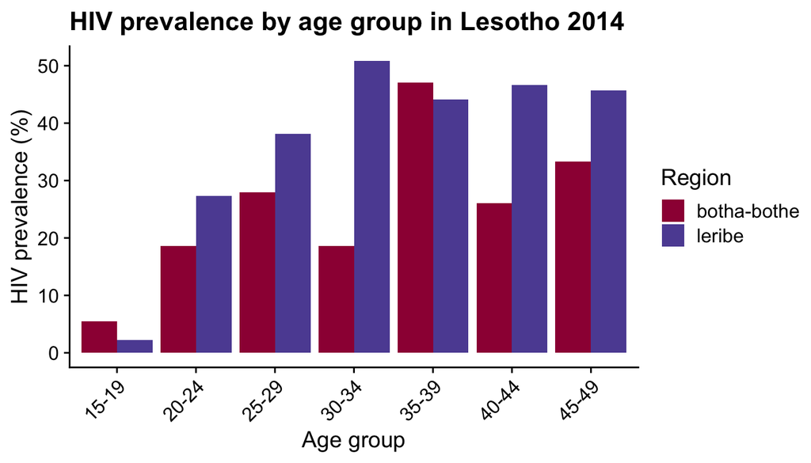

HIV Prevalence in Leribe and Botha-Bothe by age group

In Leribe 30-34 year-olds had the highest prevalence of HIV (51%), wheres in Botha-Bothe 30-34 year-olds had a low prevalence of HIV (19%). In Botha-Bothe the highest prevalence of HIV was among 35-39 year-olds (47%).

### b. HIV Prevalence in Leribe and Botha-Bothe by educational status

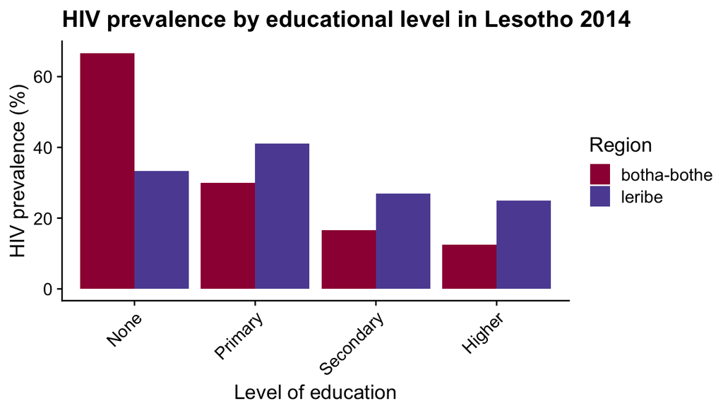

HIV Prevalence in Leribe and Botha-Bothe by educational status

### c. HIV Prevalence in Leribe and Botha-Bothe by the number of sexual partners

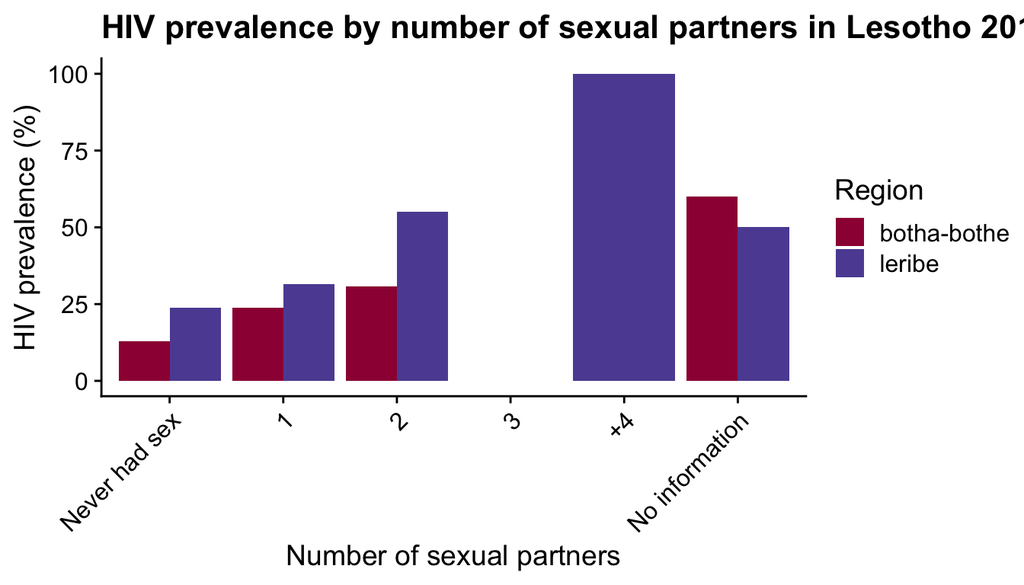

HIV Prevalence in Leribe and Botha-Bothe by the number of sexual partners

In Leribe women that had four or more sexual partners had the highest prevalence of HIV (100%). In Botha-bothe the highest prevalence of HIV was in the group that did not give any information on their sexual activity (60%).

# Conclusion